# Evaluation of sliding window correlation performance for characterizing dynamic functional connectivity and brain states - ScienceDirect

### Dependence of state identification on window length

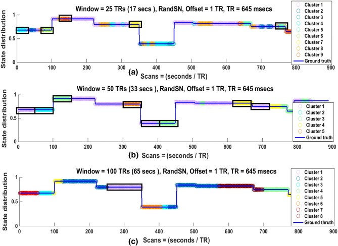

1. [Download : Download high-res image (565KB)](https://ars.els-cdn.com/content/image/1-s2.0-S1053811916001920-gr9_lrg.jpg)
2. [Download : Download full-size image](https://ars.els-cdn.com/content/image/1-s2.0-S1053811916001920-gr9.jpg)

Fig. 9. State distribution of RandSN for (a) 25 TRs, (b) 50 TRs, and (c) 100 TRs windows in one subject. Discontinuities in the blue lines indicate state transition points, while the colors of the overlaid circles represent the Cstate at each time point that was assigned by the clustering algorithm (k-means). When the circles between two adjacent state transition points remain the same color, it indicates that the state is correctly identified to be in single Cstate, while a color change at transition points indicates that the state transitions are correctly identified. None of the window correctly identifies the state transitions and durations. For smaller windows ((a) and (b)), identified state durations are mostly equal to the size of the window.

Table 1. Mean percentages of full state identifications for all SNs along with the mean percentages of the closest states that are assigned to the same cluster (Cstate, given in parentheses) for all nine subjects. Results are shown for bandpass filtered data with a window offset of one TR. The second row contains the SN type along with the total number of states (parentheses). A state was considered fully identified if it remained in the same Cstate for more than 98% of its total duration. For a specific window size, the maximum full state identification occurs for the SN with state durations equal to that window size (50 TRs window for 50SN, 100 TRs window for 100SN, and 200 TRs window for 200SN), shown in (row 4, column 4), (row 5, column 5), and (row 6, column 6). None of the windows provided good full state identification for the QPeriodicSN and RandSN. The number of actual state transitions (15 for QPeriodicSN, 10 for RandSN, 18 for 50SN, 9 for 100SN, and 5 for 200SN) was greater than the number of Cstates (mean varying between three and seven), which means that in the case of full state identifications, more than one state would be assigned to the same Cstate. The numbers in the parenthesis next to the full state identification percentages show how many of the states, which were closest to each other, are assigned to a single Cstate. Only 55% of the states assigned to the same Cstate are closest to each other compared with the other states for 50SN (50 TRs window in row 4, column 4). This percentage becomes better with an increase in the size of the window for equal duration networks (row 5, column 5 & row 6, column 6). No specific pattern is observed for the full state identification of QPeriodicSN and RandSN except that in both SNs the identification became better with the increase in the size of the window.

| Mean percentages of full state identification (mean percentages of closest states) for nine subjects for filtered (0.016–0.08 Hz) simulated networks | Mean percentages of full state identification (mean percentages of closest states) for nine subjects for filtered (0.016–0.08 Hz) simulated networks RandSN (10) | Mean percentages of full state identification (mean percentages of closest states) for nine subjects for filtered (0.016–0.08 Hz) simulated networks QPeriodicSN (15) | Mean percentages of full state identification (mean percentages of closest states) for nine subjects for filtered (0.016–0.08 Hz) simulated networks 50SN (18) | Mean percentages of full state identification (mean percentages of closest states) for nine subjects for filtered (0.016–0.08 Hz) simulated networks 100SN (9) | Mean percentages of full state identification (mean percentages of closest states) for nine subjects for filtered (0.016–0.08 Hz) simulated networks 200SN (5) |
| --- | --- | --- | --- | --- | --- |
| 25 TRs (17 s) window | 21 (97) | 9 (94) | 13 (58) | 11 (40.7) | 0 (0) |
| 50 TRs (33 s) window | 50 (64) | 58 (97) | 99 (55) | 21 (56) | 25 (56) |
| 100 TRs (65 s) window | 30 (50) | 50 (75) | 42 (66) | 100 (85) | 15 (44) |
| 200 TRs (129 s) window | 69 (59) | 65 (55) | 44 (73) | 39 (82) | 100 (97) |

Table 2. Total state transitions along with the mean percentages of correct state transitions (with respect to total detected state transitions and actual state transitions given in the parentheses) are shown for all window sizes and SNs. The second row contains the SN type along with the total number of state transitions for each one in the parenthesis. The total number of transitions is dependent on the window size as well as the actual number of states in a SN. QPeriodicSN and 50SN have the most state transitions (14 and 17) and all the windows show the maximum number of transitions for these SNs (columns 3 & 4) but the largest of them occurs for smallest window of 25 TRs (row 3, column 3 and 4). Mean percentages of correct state transitions with respect to the total and actual state transitions are largest for an equal interval SN when the window size is equal to the state durations ((row 4, column 4), (row 5, column 5), and (row 6, column 6)). Furthermore, the state transitions are fairly well identified if the window size is less the state durations.

| Mean total state transitions (mean((correct state transitions/total state transitions) × 100), mean ((correct state transitions/actual state transitions) × 100)) for nine subjects for filtered (0.016–… | Mean total state transitions (mean((correct state transitions/total state transitions) × 100), mean ((correct state transitions/actual state transitions) × 100)) for nine subjects for filtered (0.016–… RandSN (9) | Mean total state transitions (mean((correct state transitions/total state transitions) × 100), mean ((correct state transitions/actual state transitions) × 100)) for nine subjects for filtered (0.016–… QPeriodicSN (14) | Mean total state transitions (mean((correct state transitions/total state transitions) × 100), mean ((correct state transitions/actual state transitions) × 100)) for nine subjects for filtered (0.016–… 50SN (17) | Mean total state transitions (mean((correct state transitions/total state transitions) × 100), mean ((correct state transitions/actual state transitions) × 100)) for nine subjects for filtered (0.016–… 100SN (8) | Mean total state transitions (mean((correct state transitions/total state transitions) × 100), mean ((correct state transitions/actual state transitions) × 100)) for nine subjects for filtered (0.016–… 200SN (4) |
| --- | --- | --- | --- | --- | --- |
| 25 TRs (17 s) window | 39 (16, 68) | 39 (32, 90) | 44 (28, 73) | 33 (19, 81) | 42 (6, 64) |
| 50 TRs (33 s) window | 15 (37, 63) | 25 (40, 70) | 25 (59, 86) | 13 (45, 74) | 9.6 (27, 64) |
| 100 TRs (65 s) window | 13 (17, 25) | 18 (27, 33) | 15 (12, 10) | 12 (57, 86) | 5.8 (44, 64) |
| 200 TRs (129 s) window | 4.3 (15, 7) | 7.1 (3, 2) | 10 (0, 0) | 6.8 (8, 6.9) | 6 (48, 72) |

Fig. 9 illustrates the state distribution of the SWC results of RandSN for 25 TRs, 50 TRs, and 100 TRs windows. The results shown here are similar to the results of QPeriodicSN, in which each state is assigned to more than one Cstate, and state assignment is dominated by the window size, especially for smaller windows (25 TRs and 50 TRs). Fig. 8, Fig. 9 clearly identify the inefficiency of the SWC in recognizing the state transitions and durations for randomly changing networks.

### Correct state duration and transition identification

Clustering based on the SWC performed well for identifying state transitions and durations for certain combinations of SNs and window sizes but not for other combinations. In order to quantitatively analyze the SWC results, mean percentages of full state identifications and number of correct state transitions for each SN and each window size were calculated for all nine subjects. The Cstate transitions were defined by a change of cluster assignment at any time, and the identification was said to be correct if the change occurred at a state transition point. For example, if there are total ‘m’ state transitions in a SN and ‘n’ of these are coinciding with the Cstate transitions then the correct transition percentage would be $nm×100.$

A state was defined as fully identified if it remained in the same Cstate for more than 98% of its duration. Because the number of Cstates was less than or equal to number of states in the SNs (15 for QPeriodicSN, 10 for RandSN, 18 for 50SN, 9 for 100SN, and 5 for 200SN), even in the case of successful full state identification, more than one of the states would be assigned to the same Cstate. To examine how well the Cstates reflected the underlying patterns of correlation, the distance between the states assigned to a single Cstate was calculated and compared across Cstates. The mean percentages of full state identification and the mean percentages of closest states assigned to the same Cstate are given in Table 1.

As expected from Fig. 7, Fig. 8, Fig. 9, poor full state identification was achieved with small window sizes. For a 25 TRs window the percentage of full state durations assigned to the same Cstates varied from 0% to 21%. This is not surprising given the large amount of variability observed in the SWC obtained with short windows. States were identified well (> 99%) when the SN had transitions at equal intervals, and the window size was equal to the interval between transitions. The mean percentages of the closest states assigned to a Cstate was also high for 100SN and 200SN, but not for 50SN (50 TRs window) though the mean percentage of full state identification was high (99%) for this case too. This low percentage may be due to sensitivity of the window to small correlation changes and presence of spurious fluctuations.

### Effects of signal-to-noise ratio (SNR)

Various types and levels of noise are present in actual resting-state scans. Filtering the data minimizes some of the noise sources but cannot eliminate them completely. In order to examine the influence of noise, we added random additive white Gaussian noise (AWGN) at levels of 10 dB and 20 dB to all SNs before performing the SWC. The SWC results of one node pair in 100SN for the 100 TRs window are shown in Fig. 10, since this combination of state and window length performed best for the noise-free case. The addition of noise reduced the actual correlation and lessened the sharp state transitions in the SWC results. Higher levels of noise had stronger effects.

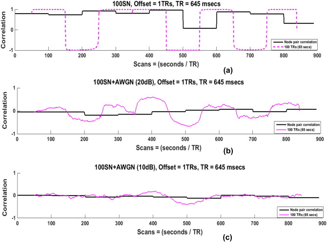

1. [Download : Download high-res image (404KB)](https://ars.els-cdn.com/content/image/1-s2.0-S1053811916001920-gr10_lrg.jpg)
2. [Download : Download full-size image](https://ars.els-cdn.com/content/image/1-s2.0-S1053811916001920-gr10.jpg)

Fig. 10. Actual correlation and SWC of one node pair (100SN for 100 TRs window) before addition of the noise in (a) and after addition of additive white Gaussian noise (AWGN) with an SNR of 20 dB in (b) and 10 dB in (c). Noise reduces the sharp transitions of the SWC results. The identification of transition points becomes more difficult for small SNR (c) compared with large SNR (b).

Fig. 11 shows the state distribution of the noisy 100SN for 100 TRs windows. As expected from the result of the SWC for a node pair, the state transitions are lost after the addition of noise as can be observed from the lack of a color change at the discontinuities in (b) and (c). Similar results were observed for other regularly changing SNs (50SN for 50TRs window and 200SN for 200 TRs window).

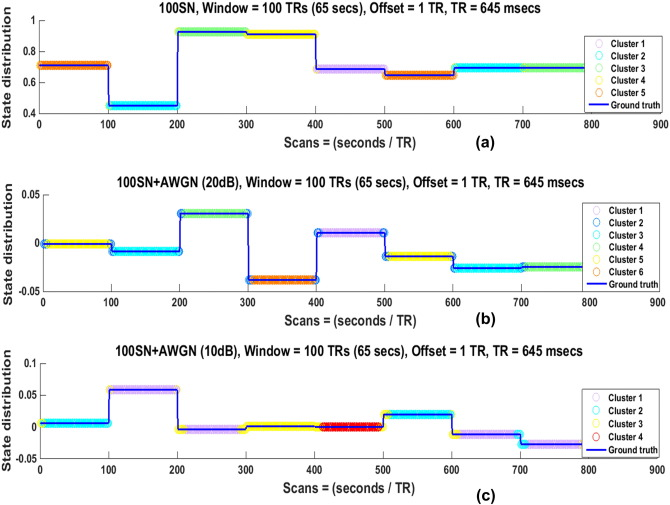

1. [Download : Download high-res image (561KB)](https://ars.els-cdn.com/content/image/1-s2.0-S1053811916001920-gr11_lrg.jpg)
2. [Download : Download full-size image](https://ars.els-cdn.com/content/image/1-s2.0-S1053811916001920-gr11.jpg)

Fig. 11. State distribution of 100SN for 100 TRs window before addition of the noise in (a) and after addition of additive white Gaussian noise (AWGN) with an SNR of 20 dB in (b) and 10 dB in (c). Addition of noise resulted in poorer identification of state transitions.

We also examined a more typical reduction in SNR for rs-fMRI by taking a single voxel as a node of our SNs instead of 3 × 3 × 3 voxel ROIs. All analysis was performed on seven of the nine subjects for four SNs (RandSN, 50SN, 100SN, and 200SN) and mean percentages of full and closest state identifications are shown in Supplementary Table 1. The results indicate that higher SNR improves the estimation of SWC, state durations, and transitions.

### Effects of window offset

Up to this point all of the results were shown for a window offset of one TR (645 ms). Since some previous studies have used larger offsets (Chang and Glover, 2010; Chang et al., 2013, Kucyi and Davis, 2014; Wilson et al., 2015), we also explored the effect of larger offsets on the SWC and the resulting Cstates. It was observed earlier in this study (Fig. 7(c)) that for a window of size 100 TRs applied to 100SN, the SWC transitioned at the point of the actual state change. When the same 100 TRs window is applied to 100SN but with a window offset of one-fourth (25 TRs) or one-half (50 TRs) the window length, an additional transition occurring at approximately 25 TRs (50 TRs) after the transition at the state change point is introduced into the SWC time course (Supplementary Figs. 16(b) and (c), blue oval markers show one of these additional transitions in each of these figures).

We also plotted state distributions for 100SN with a 100 TRs window for an offset of one TR, an offset of 25 TRs, and an offset of 50 TRs (Supplementary Fig. 17). State durations were successfully identified for an offset of one TR, but not for an offset of 25 TRs and 50 TRs. Almost all of the actual states were separated into two Cstates in both cases, one of which was equal to the duration of the offset (black ovals). Results were consistent across all windows and all SNs.

### Effects of window type

A rectangular window was used for the majority of our simulations, similar to most of the previous dynamic FC studies (Keilholz et al., 2013, Shakil et al., 2014, Leonardi and Van De Ville, 2015), but we also explored the effects of window type on the SWC results. Hamming and Hanning windows of the same lengths as the rectangular windows (25 TRs, 50 TRs, 100 TRs, and 200 TRs) were used for the SWC computations. The state distributions for a Hamming window for 50SN, 100SN, and 200SN and windows lengths of 50 TRs, 100 TRs, and 200 TRs respectively are shown in Supplementary Fig. 18. Results for the Hanning window were similar. The Cstates are not localized to true correlation states and state transitions are poorly identified. The results for both tapered windows were worse than those obtained for rectangular windows, possibly because the SNs in our model have sharp discontinuities that are tracked better by rectangular windows.

### Effects of filtering

Recent studies showed that the SWC for two [sinusoids](https://www.sciencedirect.com/topics/medicine-and-dentistry/sinusoid) approaches the steady state value only if the window size ≥ 1/f<sub>min</sub>, where f<sub>min</sub> is the minimum frequency of the correlating time series (Leonardi and Van De Ville, 2015; Shakil et al., 2015). To determine if matching the lowest frequency in the time course of the signals to the window size impacts the calculation of the SWC and corresponding clustering in more complex data, we performed the same analysis on the SNs created using highpass filtered (> 0.016 Hz, > 0.05 Hz, and > 0.08 Hz) time series. Based on the findings of (Leonardi and Van De Ville, 2015; Shakil et al., 2015), windows of size greater than or equal to 62.5 s (for f<sub>min</sub> = 0.016 Hz), 20 s (for f<sub>min</sub> = 0.05 Hz), and 12.5 s (for f<sub>min</sub> = 0.08 Hz) would result in the SWC approaching the steady state values for our highpass filtered SNs. The SWC between the node pairs were computed and compared with the actual correlations for these highpass filtered SNs. The results for one node pair for 100SN are given in Fig. 12. We observed decrease in the SWC values for almost all of our windows (17, 33, 65, 129 s) when f<sub>min</sub> was 0.08 Hz (row 3), but this reduction was more noticeable for larger windows and did not follow the steady state correlations shown by black lines. Furthermore, increasing the highpass cutoff also resulted in the loss of sharp transitions at the state change point even when the window size was the same as the state duration, which can be observed in row 3 (c). The state transitions and duration detections were not strongly influenced by the lower cutoff values of the ideal case (100SN with 100 TRs window) as shown in Supplementary Fig. 19. However, there was some error in the detection of state transitions (Supplementary Fig. 19(c)). This deterioration may be the result of the SWC's inability to detect the state transitions for higher cutoffs as was observed in Fig. 12 (row 3 (c)). Since most of the power in the low frequency BOLD fluctuations lie in the very low frequencies (< 0.1 Hz), the filters with higher cutoffs discard much of the information. Similar results were observed in all the subjects.

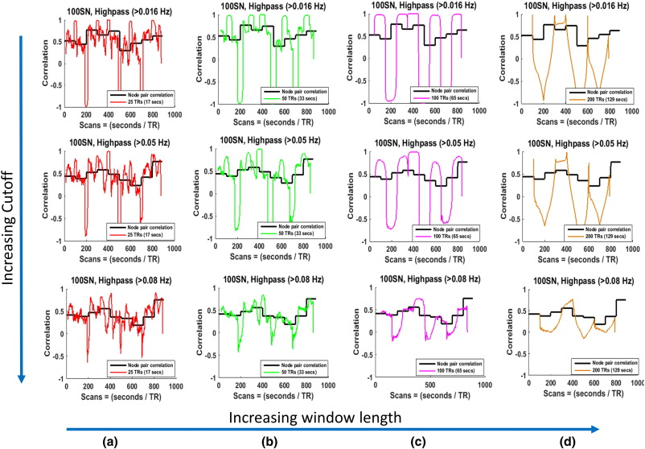

1. [Download : Download high-res image (922KB)](https://ars.els-cdn.com/content/image/1-s2.0-S1053811916001920-gr12_lrg.jpg)
2. [Download : Download full-size image](https://ars.els-cdn.com/content/image/1-s2.0-S1053811916001920-gr12.jpg)

### Effects of the change in the repetition time

The simulations described up to this point were performed using high temporal resolution data acquired using a multiband sequence. Most rsfMRI studies, however, are performed with longer TRs (1–3 s), which results in a lower sampling rate and provide fewer points in any given window. To examine the effect of this reduction in samples, the same analysis was performed using data from scans with 1400 ms TR for two subjects for low SNR SNs formed by single voxels as nodes. RandSN changed states at random times, while 50SN, 100SN, and 200SN changed states after every 24 TRs, 47 TRs, and 93 TRs, respectively giving the states almost the same durations in seconds as that of the SNs formed with 645 ms TR scans. Window sizes of 13, 24, 47, and 93 TRs (≈ 19, 34, 66, 131 s) were used, which were almost equal (in seconds) to the sizes of the windows used for the 645 ms TR scans. The results of the analysis were similar to the results for the 645 ms TR scans, illustrating that the outcome of the SWC depends more strongly on the size of the window (in seconds) used than on the TR of the scans. We did not perform this analysis on higher SNR ROI based SNs because the results were so similar for the voxel-based SN case.

## Discussion

Dynamic analysis of resting state FC holds the potential to provide new insights into the organization and interplay of network activity in the brain. Already it has been shown that dynamic analysis can improve sensitivity to changes that occur in [psychiatric disorders](https://www.sciencedirect.com/topics/neuroscience/psychopathology) (Sakoğlu et al., 2010, Jones et al., 2012, Damaraju et al., 2014, Li et al., 2014). One of the major challenges in furthering the field of dynamic FC is a lack of gold standards that can be used to evaluate how well analysis techniques reflect the actual network interactions in a system where the timing, duration, and composition of states are all unknown.

Previous studies have taken two approaches to the problem, either linking network dynamics to measurable behavioral outputs (Thompson et al. 2013, Kucyi and Davis, 2014) or tying them to simultaneous measures of electrical activity made with other modalities (Tagliazucchi et al., 2012, Chang et al., 2013, Pan et al., 2013, Thompson et al., 2013a, Thompson et al., 2013b). These studies impart confidence that dynamic analysis methods reflect at least some of the underlying neural dynamics. However, they do not readily adapt to a systematic investigation of analysis techniques and parameters.

SWC is one of the simplest and most widely used approaches to dynamic functional analysis, and is sometimes followed by clustering to identify common states of correlation patterns throughout the brain (Allen et al., 2014, Shakil et al., 2014). Most [dynamic functional connectivity](https://www.sciencedirect.com/topics/medicine-and-dentistry/dynamic-functional-connectivity) studies use SWC but the method's performance depends on the choice of parameters like window length, offset etc. In this study, we formed SNs from real rsfMRI data in order to obtain SWC results similar to those of real FC networks but with controlled state transition times.

Two recent studies (Hindriks et al., 2015, Shine et al., 2015) analyzed the performance of the SWC for dynamic analysis and identified shortcomings of the method. (Hindriks et al., 2015) reported that the mere presence of fluctuations in the SWC time series cannot be taken as the evidence of dynamic functional connectivity and that it is important to select an appropriate null hypothesis when performing the dynamic FC analysis and (Shine et al., 2015) compared their proposed method with the SWC. Our approach complements these studies since similar to Shine et al. (2015), we observed a significant influence of a change in signal amplitude on the SWC results for all windows (Fig. 3, Supplementary Figs. 8 and 9). We also observed spurious fluctuations in the results of the SWC for actual rsfMRI networks (Fig. 2) and for the SNs (Fig. 3, Supplementary Figs. 8 and 9), supporting the findings of Hindriks et al. (2015) that the mere presence of fluctuations in the SWC results cannot be taken as evidence of dynamic FC. These similarities in the results validate the use of our SNs for evaluating the impact of parameter choice on the performance of SWC.

SWC has successfully identified changes linked to electrophysiology, behavior or disorders in previous studies (Tagliazucchi et al., 2012, Chang et al., 2013, Thompson et al., 2013a, Thompson et al., 2013b; Damaraju et al., 2014, Li et al., 2014), despite its relatively poor performance in this study. As mentioned in the Sharp transitions section, our simulated networks are only approximations of actual brain states, which may not exhibit the same sharp state transitions. However, there are several reasons why SWC could perform adequately in previous studies. First, it is important to note that the “ground truth” in these empirical studies is unknown, preventing an examination of the accuracy of the SWC measurements. Instead, BOLD SWC is compared to other measures of neural activity, behavioral output, or across populations. In studies that relate SWC of BOLD to sliding window measures of neural activity (Tagliazucchi et al., 2012, Chang et al., 2013, Thompson et al., 2013a, Thompson et al., 2013b), the sliding windows might affect both signals in a similar manner, preserving relationships between them. In studies that look at transitions and states across groups (Damaraju et al., 2014, Li et al., 2014), a similar effect may be preserving the differences between groups even if the actual correlation is poorly estimated. For comparison to behavior, ROIs are often large and may increase the SNR enough to improve SWC performance (Thompson et al., 2013a, Thompson et al., 2013b).

The effects of different parameter choices for the SWC and clustering were examined using these model networks. While the SNs were created using data from actual [resting state networks](https://www.sciencedirect.com/topics/medicine-and-dentistry/resting-state-network), several implicit assumptions may affect their similarity to actual networks in the brain:

**1)**

All nodes were assumed to be connected at all times. The SNs were spatially invariant, meaning that nodes did not join or leave the network at any time.

**2)**

Abrupt transitions occurred between consecutive states. In practice, the characteristics of ‘state’ transitions in the brain are not known, but it is likely that smoother transitions over the course of seconds occur alongside or instead of abrupt transitions.

**3)**

The average duration of a real brain ‘state’ is not known. For our study it was modeled as 13 to 129 s, ranging from time scales on the order of a cohesive thought to more long-term changes (in vigilance, for example) that occur on the scale of minutes. It is likely that these time scales are expressed simultaneously in the actual brain.

These assumptions are excellent targets for future extensions of this work and more complex model networks may prove more realistic for examining the accuracy of dynamic analysis techniques. Nevertheless, this simple model provides some guidance about the impact of parameter choice on the SWC.

### Sharp transitions

Despite the fact that the data in our SNs was from rsfMRI scans, our SNs had sharp state transitions as shown in Fig. 1 and Supplementary Fig. 4, which is different from the gradual changes expected in real resting-state networks. These sharp state transitions were due to abrupt changes in the signal intensities at the state transition points (Lindquist et al., 2014) that acted as outliers, especially for smaller windows (25 TRs, 50 TRs) in which the averaging in the SWC includes a smaller number of points. Although the transitions in our SNs may not reflect the actual state transitions of rsfMRI networks, they clearly identify the important issue of SWC's very high sensitivity to even one large short-lived intensity change which may happen due to some form of noise. Similar to the results of actual rsfMRI networks (Fig. 2., Supplementary Fig. 7) and previous studies (Hutchison et al., 2013a, Hutchison et al., 2013b; Keilholz et al., 2013, Wilson et al., 2015) the SWC fluctuated between negative and positive values even when the actual correlation was positive for the SNs. Furthermore, similar to Wilson et al. (2015) we observed that despite the large variations for smaller windows, the pattern and timings of these correlation variations were the same. For example, in Fig. 3, the − 1 correlations appear almost at the same points for all the windows, though other lesser variabilities are smoothed out by an increase in the size of the window, as expected. However, our results differ from those of Wilson et al. (2015) in the sense that the correlations vary between extreme values of − 1 and 1 regardless of the actual correlation values between two state transition points. A closer inspection of these results show that these variations are mostly accompanied by abrupt signal changes at state transition points. Once the SWC value changed at the state transition point, it remained the same in most of the cases till the next abrupt signal change (at the next state transition point) especially for longer windows (pink and brown). This may be because the data between two consecutive state transition points was from the same resting-state networks so would not have any abrupt changes in signal. For smaller windows (red and green) the window size was less than 1/f<sub>min</sub> which may have introduced spurious fluctuations (Leonardi and Van De Ville, 2015; Shakil et al., 2015). These results emphasized the vulnerability of the SWC as an efficient and effective dynamic analysis method for FC. While sharp transitions are troublesome for SWC, the same sharp transitions in our SNs in some sense provided a “best case scenario” for clustering, with distinct boundaries between states that resulted in efficient clustering performance by k-means, with perfect identification of state transitions and durations in the raw SNs.

### Window length

As expected, window length had a substantial effect on the amount of variability captured by the SWC and was the single most important determinant of the overall accuracy of the technique. Smaller windows (17 and 33 s) had more variability in the SWC results regardless of the SN. Some of these fluctuations maybe the result of spurious fluctuations arising from the SWC algorithm itself based on the findings of recent studies (Leonardi and Van De Ville, 2015; Shakil et al., 2015). In these studies it was reported that the minimum window length to avoid the spurious fluctuations arising due to the SWC itself should be at least equal to 1/f<sub>min</sub>, where f<sub>min</sub> is the minimum frequency in the simplified correlating signal. In our study the f<sub>min</sub> is 0.016 Hz that corresponds to a minimum window length of 62.5 s and window lengths less than this (17 and 33 s) would give rise to spurious fluctuations. Regardless of window length, we found the overall correspondence between the actual correlation and the SWC to be rather poor. SWC results were more divergent from the actual correlation values at the time of state transitions illustrating that even a single outlier or abrupt change can have significant influence on the SWC output (Lindquist et al., 2014). This effect was more pronounced for smaller windows, since the averaging of SWC includes a smaller number of samples, and a large change in the value of even one sample would greatly influence the averaging. Furthermore, smaller windows would introduce spurious fluctuations also (Leonardi and Van De Ville, 2015; Shakil et al., 2015). Window sizes that were well matched to the duration of the states provided fairly good sensitivity to state transitions but still gave poor estimates of the actual correlation values. Perhaps because of the sensitivity to transitions, clustering after the SWC provided surprisingly good state identification for window lengths well matched to state durations, despite the poor estimation of correlation values. To some degree, the clustering was able to salvage information from the relatively poor accuracy of the SWC time courses. However, this was only true for certain situations where window lengths aligned well with state durations. It was also noted that in some situations, the duration of Cstates appears to be dominated by the window length rather than by the actual underlying state durations. Surprisingly, the clustering of raw SNs resulted in perfect state transition and duration identifications, giving far better performance than when SWC was used. These ideal results may be due to the sharp state transitions of our SNs which would provide distinct grouping to the clustering algorithm. However, these results also suggest that the application of the SWC is in general detrimental to the identification of brain states, and that clustering based on raw data provides a cleaner estimate of the patterns of underlying activity. If windowing methods are used, the results of these simulations highlight the need for development of adaptive techniques to maximize sensitivity to states of different durations.

Inter -subject variability was influenced by the size of the window more than the type of the SN. The smaller windows could capture the short-lived variabilities of the node pair correlations much better than the larger windows as is evident from Fig. 4 and Supplementary Fig. 7. However, the largest correlation was present for 200SN in almost all the subjects for all windows because the states were stable for the longest duration (200 TRs). This result suggests that the SWC could perform well when the underlying network is changing very slowly.

### Signal-to-noise ratio (SNR)

Additive white Gaussian noise (AWGN) deteriorated the results of both SWC and k-means clustering since it reduced the identification of sharp state transitions. This AWGN (20 dB and 10 dB SNRs) was added to the whole length of time series in SNs. This resulted in less sharp state transitions and the SWC result being closer to actual correlation value influencing the state assignments of the SWC results even for best case scenarios (50SN with 50TRs, 100SN with 100 TRs windows, and 200SN with 200 TRs window). The noise that we added was random, but actual noise is rsfMRI often arises from physiological sources (heart beat at ≈ 1 Hz, respiration at ≈ 0.3 Hz) and head motion (Kruger and Glover, 2001; Greve et al., 2013, Bright and Murphy, 2015) and is spatially structured. These types of noise may introduce structured deterioration in the SWC results which may introduce smooth but large variability in the correlation resulting in poor performance of the SWC in estimating the actual correlation. Influence of these structured noises is reduced during the preprocessing by filtering (heart and respiration) and regressing (motion parameters), however, they cannot be eliminated completely. In addition, the different filtering ranges are used (0.01–0.08 or 0.01–0.1 Hz usually) which may also influence the final output as discussed in the Time domain filtering section and reported by Leonardi and Van De Ville (2015) and Shakil et al. (2015).

### Number and size of ROIs

For actual FC networks the number of ROIs is different for different networks. For example, the atlas used in this study (from FIND lab, http://findlab.stanford.edu/home.html) has a total of 90 functional ROIs and out of these the number of ROIs for different FC networks vary from two (primary and higher visual networks) to twelve (post salience network). However, another expanded atlas by the same lab covering more gray matter contains 499 functional ROIs. The selection of seven nodes (ROIs) for our SNs was random but this number had no influence on the results of the SWC between the node pairs and affected the results of clustering only in that fewer nodes gave poorer clustering results. We performed an additional analysis by reducing the number of nodes to three and clustered the SWC using k-means. In that analysis for most of the cases, the best Silhouette mean was obtained for two clusters only, which would result in assignment of different states to the same Cstates and deteriorate the clustering results. Increasing the number of nodes should improve the state assignments as each additional node provides more information that can be used to distinguish between states.

Sizes of the ROIs in actual FC networks range from a few voxels to hundreds of voxels. In this study we found that the size of the ROI influences the results of the SWC because the SNR depends on the size of the ROI. Reducing the size of the ROI to a single voxel deteriorated the correct state identifications (Supplementary Table 1) compared to larger ROIs (Table 1). As a result, it may be deduced that the SWC and k-means combination would provide better estimates of actual correlations and state distributions if bigger ROIs were used that are similar to ROIs of real FC networks.

### Window offset

An offset of a single TR proved best for detecting both state changes and durations. Increasing the window offset reduced the sensitivity of the SWC towards the correlation changes, as well as its ability to detect state transitions and durations. The larger the offset, the worse the results became. A closer inspection of the results showed that this deterioration may be due to shifts in the SWC results due to uncertainty in the times which best reflect the average in the window, and to the introduction of new transitions at intervals equal to the offset. To some extent, this may be related to the sharp transitions between networks used for this study and could well be mitigated for networks with more gradual transitions.

### Time domain filtering

Typical rsfMRI scans use a bandpass filter to minimize contributions from noise (typically 0.01–0.1 Hz or 0.01–0.08 Hz). Following the findings of Leonardi and Van De Ville (2015) and Shakil et al. (2015), we applied highpass filters with different frequency cutoffs to the data. We observed that the highpass filtered SNs provide results similar to bandpass filtered networks when the highpass cutoff was the same as the that of the bandpass lower cutoff. As we increased the highpass cutoff to higher values (> 0.05 Hz and > 0.08 Hz) magnitudes of the SWC results for windows larger than 1/f<sub>min</sub> were reduced, but the ability of the SWC to follow actual correlation values did not improve though the sharp state transitions of the SWC results were lost. The ability of the clustering algorithm to identify state transitions deteriorated, particularly for larger windows. This suggests that in our model, other sources of variability dominate the signal rather than the instability introduced by a mismatch in frequency and window length. One reason for the differences observed from Leonardi and Van De Ville (2015) and Shakil et al. (2015) may be that in our case, correlations were computed for the duration of the states, rather than for the whole scan time, making the sample length shorter. In some sense, the finding that the inclusion of lower frequencies does not greatly impact the performance of the SWC is encouraging. The combined requirements of highpass filtering to match the window length and low pass filtering to limit contributions from noise would place rather stringent limits on the range of windows that could be used to examine the SWC dynamics. The unfortunate corollary of this finding is that since the inclusion of lower frequencies does not greatly impact the SWC, the highpass filter does not appreciably improve the SWC performance, leaving it far from ideal as an analysis technique.

### Repetition time (TR)

TR did not substantially affect the results of the SWC as far as sensitivity towards correlation changes and state identification were concerned. While shorter TRs provide more samples which should theoretically improve the estimation of correlation values, longer TRs often provide stronger [signal-to-noise ratios](https://www.sciencedirect.com/topics/medicine-and-dentistry/signal-to-noise-ratio) that could offset this effect. As many rsfMRI studies routinely use TRs of 1–3 s, it is encouraging to see that the reduced sampling rate can have a minimal effect on the SWC and clustering.

### Considerations for future SWC studies

Finally, the results of the SWC applied to QPeriodicSN and RandSN (arguably the most realistic models for the types of transitions expected in rsfMRI) highlight the way that window size impacts the resulting states. A large proportion of the states identified were approximately equal in length to the sliding window, regardless of the length of the actual state duration. This may be an important point to consider during the interpretation of the SWC-based clustering on real rsfMRI data.

A surprising and novel aspect of this study was perfect state transition and duration identification obtained using k-means clustering on the raw SN signal. These ideal results may be partly due to abrupt transitions of our SNs and will require further examination. However, they suggest that researchers may wish to consider using clustering-based approaches on the raw signal to identify the states of FC, rather than the SWC time courses whenever possible.

## Future directions

This study evaluated the performance of the SWC as a suitable method for capturing network dynamics with rsfMRI. After examining the effects of various parameters on the dynamic analysis results of the SWC, we observed that no set of parameters were suitable for optimum performance of the SWC under conditions that are likely to exist in the human brain (e.g., random lengths of state durations). Windows that matched the intervals at which brain states changed provided the most accurate information, but this situation is unlikely to be found in rsfMRI.

The clear outcome of this study is the need to develop algorithms that can adaptively detect state transitions of different durations. This is a clear target for future research and may be addressed by the use of multiscale approaches (e.g., wavelet-based analysis) that can simultaneously examine multiple time scales. An ideal analysis method would identify each state based on quantitative relationships between areas, along with transition points between states. The challenge of identifying an optimum number of ‘brain states’ is another target for future efforts.

Any algorithm that aims to address these issues will need to be tested against modeled network dynamics, but even the best performance on a model network will not guarantee success in identifying transitions of interest in actual rsfMRI data. Validation with multimodal data and behavioral outputs will be necessary to conclusively establish a link between the output of the algorithm and activity within the brain. Despite the large amount of work, remaining, dynamic rsfMRI has the potential to have a profound impact on our understanding of the brain.

## Acknowledgments

This research was supported by NIH R01NS078095. The authors would like to thank their lab members Mr. Joshua Grooms and Mr. Jacob Billings for being helpful by discussing various aspects of this study. The authors would also like to thank their lab members Mr. Anzar Abbas and Mr. Hyun Koo Chung for proofreading the paper.

## Appendix A. Supplementary data

[Download : Download Powerpoint document (4MB)](https://ars.els-cdn.com/content/image/1-s2.0-S1053811916001920-mmc1.pptx)

Supplementary Fig. 1. The anatomical localization of the functional regions-of-interest (ROIs) of (a) dorsal DMN (PCC/MPFC), (b) ventral DMN (RSC/MLT), (c) anterior salience (insula/dACC), (d) visuospatial (IPS/FEF), and (e) sensorimotor networks. These ROIs are taken from supplementary data of Shirer et al. (2012).

Supplementary Fig. 2. Masks of the functional networks taken from supplementary data of Shirer et al. (2012) at FIND lab (http://findlab.stanford.edu/home.html). (a) Dorsal DMN network. (b) Ventral DMN network. (c) Anterior [salience network](https://www.sciencedirect.com/topics/medicine-and-dentistry/salience-network). (d) Visuospatial network. (e) Sensorimotor network. The colored regions in any of these networks are the regions-of-interests (ROIs) defined by the FIND lab and their sizes are different. However, in this study the ROIs are defined as non-overlapping 3 × 3 × 3 voxels extracted from these bigger ROIs. The ROIs in this study are pointed to by the red and green arrows. The size of the ROIs defined by FIND lab is generally greater than 3 × 3 × 3 voxels so more than one non-overlapping ROIs (of size 3 × 3 × 3) could be extracted from the same ROIs of the original functional networks.

Supplementary Fig. 3. Entirely different sets of ROIs (3 × 3 × 3) selected from the actual [resting-state networks](https://www.sciencedirect.com/topics/medicine-and-dentistry/resting-state-network) for comparison purpose. The summarized mean state percentages of full state identification for these ROIs are shown in Supplementary Table 2.

Supplementary Fig. 4. Means and standard deviations of pairwise stationary correlations of node pairs of the actual resting-state networks. Each network consisted of seven nodes (3 × 3 × 3 voxels ROIs). The mean correlations range between 0.4 and 0.74 and the standard deviation is between 0.14 and 0.34.

Supplementary Fig. 5. Log–log plots of power spectrum vs. frequency for all the time series of actual networks (a) and simulated networks (b). The general distribution of frequency spectrum is similar, however, there are non-smooth power changes in the plots of SNs due to sudden transitions. There is no one to one correspondence between the plots in (a) and (b). The plots in (b) are formed by taking the time series on networks in (a) for different durations.

Supplementary Fig. 6. Ground truths (GTs) for (a) 50SN and (b) 200SN. 50SN has state transitions at every 50 TRs (33 s) and 200SN has state transitions at every 200 TRs (129 s), Each SN has seven nodes and ground truth for any SN is the mean of actual correlations of all of its node pairs.

Supplementary Fig. 7. Stationary and sliding window correlations of three node pairs (selected at random) from three different resting-state networks. Stationary correlations of the node pairs are shown by black horizontal lines. The SWCs for all the windows are overlaid on each other to observe the extent of variability with respect to each other. The SWC is fluctuating around the stationary correlation and these fluctuations are largest for smallest window (red) and smallest for the largest window (brown).

Supplementary Fig. 8. Actual correlations and SWCs for one node pair in 50SN (row 1) and 200SN (row 2). The SWC is plotted for windows of 25 TRs, 50 TRs, 100 TRs, and 200 TRs (≈ 17, 33, 65 and 129 s). The window offset is one TR and filtered (0.016–0.08 Hz) time series are used. The actual correlation between the node pair is plotted in black. Smaller windows (red, green) result in more variable correlation time series. The large amount of variability indicate the ability of smaller windows to capture short-lived correlations, but some of these variations may be due to the spurious fluctuations introduced due to small size of the window. The transitions in the SWC results occur at an interval of 33 s (50 TRs) for 50SN when the state duration and window size are the same (green dashed). The same trend is observed for 200SN for 200 TRs window (brown dashed). These results show that SWC is good at identifying the transition of states under specific conditions only.

Supplementary Fig. 10. Stationary correlations between the actual and sliding window correlations of all node pairs of all the SNs were computed for each subject. Mean correlations for all node pairs of each subject are plotted separately. Overall correlations are not very high for any window, but in general the correlations for all SNs are higher for the smallest window (blue) compared to larger ones. Furthermore, in general the correlations are higher for 200SN for all the windows.

Supplementary Fig. 11. Silhouette indexes for raw SNs for eight subjects (silhouette index for ninth subject is plotted in Fig 5(a)). The highest silhouette values (red dots and green arrows) corresponding to the best number of clusters for all the raw SNs in all the subjects were five since the SNs were formed from five resting-state networks.

Supplementary Fig. 12. The silhouette indexes for SWC results were different for different windows for all subjects. However, for the same window length, a similar range of silhouette values can be observed, as shown from the concentration of the same colors at the same locations in plots of all the subjects.

Supplementary Fig. 13. Clustering of raw SNs (a) 50SN and (b) 200SN using k-means. All the SNs were formed from five resting-state networks (dorsal DMN, ventral DMN, visuospatial, anterior-salience, and sensorimotor) and so were divided into five clusters. The division of the raw network signal gives perfect state transitions and durations.

Supplementary Fig. 14. State distribution of SWC results of 50SN for one subject. The best number of clusters (Cstates) in each case is identified by silhouette criteria. Discontinuities in the blue lines indicate that state transition points and the colors of the overlaid circles represent the Cstate at each time point that was assigned by the clustering algorithm (k-means). When the circles between two adjacent state transition points remain the same color, it indicates that the state is correctly identified to be in single Cstate, while a color change at transition points indicates that the state transitions are correctly identified. (a) State distribution for a 25 TRs window. State transitions and distributions are not identified reliably in this case. (b) State distribution when the window size is equal to the state duration of 50 TRs. The state transitions are correctly identified as seen by the change of color at the discontinuities. Furthermore, the state durations are also identified reliably as shown by consistent assignment of each actual state to a single Cstate. (c) State distribution when the window size [is 100](https://www.sciencedirect.com/topics/medicine-and-dentistry/pimeprofen) TRs. State transitions and distributions are not identified reliably. In all of these figures it can be observed that the state distribution is influenced by the window size with shortest identifications in (a) and longest in (c).

Supplementary Fig. 15. State distribution of SWC results of 200SN for one subject. The best number of clusters (Cstates) in each case is identified by silhouette criteria. Discontinuities in the blue lines indicate that state transition points and the colors of the overlaid circles represent the Cstate at each time point that was assigned by the clustering algorithm (k-means). When the circles between two adjacent state transition points remain the same color, it indicates that the state is correctly identified to be in single Cstate, while a color change at transition points indicates that the state transitions are correctly identified. (a) State distribution for a 50 TRs window. State transitions and distributions are not identified reliably in this case. (b) State distribution when the window size is equal to 100 TRs. State transitions and distributions are not identified reliably. (c) State distribution when the window size is equal to the state duration of 200 TRs. The state transitions are correctly identified as seen by the change of color at the discontinuities. Furthermore, the state durations are also identified reliably as shown by consistent assignment of each actual state to a single Cstate. In all of these figures it can be observed that the state distribution is influenced by the window size with shortest identifications in (a) and longest in (c).

Supplementary Fig. 16. Effect of increasing the window offset (shift) on the SWC results. Each plot shows the real correlation between one node pair (black) and sliding window correlation for the same node pair (pink). (a) The SWC for the 100SN for 100 TRs window has transitions at the state transition points for an offset of one TR. (b) Increasing the offset to one-fourth the window length (25 TRs) resulted in the additional transitions along with the actual transitions after a time equal to the offset (blue oval illustrates one such transition). (c) Increasing the offset to one-half the window length (50 TRs) resulted in the additional transitions along with the actual transitions after a time equal to the offset (blue oval illustrates one such transition).

Supplementary Fig. 17. State distribution of the SWC results of the 100SN for a window of size 100 TRs for an offset of (a) 1 TR and (b) 25 TRs, and (c) 50 TRs. It can be observed from (b) and (c) that increase in offset results in incorrect full state duration identification for both the cases, for the same case that gave correct full state duration identification for an offset of one TR (a). Another point to be noted is that the shifts divide the state durations in two parts one of which is equal to the amount of the shift (shown by black ovals in (b) and (c)) for one such division for each shift.

Supplementary Fig. 18. State distribution for (a) 50SN, (b) 100SN, and (c) 200SN for windows of sizes 50 TRs, 100 TRs and 200 TRs respectively for an offset of 1 TR using hamming window for sliding window correlation. Both the state duration and transition identifications are poor. The sliding window seems to identify one state very frequently, which can be observed by high concentration of the same color circles in all three plots.

Supplementary Fig. 19. State distribution for 100SN for 100 TRs window with highpass filtered data with cutoff of (a) 0.016 Hz, (b) 0.05 Hz, and (c) 0.08 Hz. It can be observed that the results state distributions for all three cases are almost identical to the bandpass filtered (0.01–0.08 Hz) SNs. However, increasing the highpass cutoff influences the state transitions as can be seen by the change of color at some of the discontinuities in (c). It maybe since the sharp transitions in the SWC results are reduced with the increase of the highpass cutoff.

Supplementary Table 1. Effect of reducing the SNR by reducing the node size. Mean percentages of full state identifications for all voxel based RandSN, 50SN, 100SN, and 200SN along with the percentages of the closest states that are assigned to the same cluster (Cstate, given in parentheses) for seven subjects. Results are shown for bandpass filtered data with a window offset of one TR. The second row contains the SN type along with the total number of states (parentheses). A state was considered fully identified if it remained in the same Cstate for more than 98% of its total duration. Comparison with Table 1 shows that the percentages of correct state identifications are reduced for single voxel SNs compared with ROI based SNs even for regularly changing SNs with the same window size (red entries). Furthermore, the SWC was not able to correctly identify any states for some cases as can be observed from the zero entries. However, an increase in SNR due to an increase in the node size improved this, as can be seen by all non-zeros entries in Table 1.

Supplementary Table 2. Mean percentages of full state identification shows the same trend for the SNs formed from different sets of ROIs, as can be observed for highest means when the window size is the same as the state durations (red).

## References

**Allen et al., 2014**

E. Allen, E. Damaraju, S. Plis, E. Erhardt, T. Eichele, V. Calhoun

**Tracking whole-brain connectivity dynamics in the resting state**

Cereb. Cortex, 24 (3) (2014), pp. 663-676, 10.1093/cercor/bhs352

[CrossRef](https://doi.org/10.1093/cercor/bhs352)[View Record in Scopus](https://www.scopus.com/inward/record.url?eid=2-s2.0-84894232779&partnerID=10&rel=R3.0.0)Google Scholar

**Bright and Murphy, 2015**

M. Bright, K. Murphy

**Is fMRI “noise” really noise? Resting state nuisance regressors remove variance with network structure**

NeuroImage, 114 (1) (2015), pp. 158-169, 10.1016/j.neuroimage.2015.03.070

[Article](https://www.sciencedirect.com/science/article/pii/S1053811915002669)[Download PDF](https://www.sciencedirect.com/science/article/pii/S1053811915002669/pdfft?md5=43b73ce90db57c62b46684515e39b590&pid=1-s2.0-S1053811915002669-main.pdf)[View Record in Scopus](https://www.scopus.com/inward/record.url?eid=2-s2.0-84937765110&partnerID=10&rel=R3.0.0)[Google Scholar](https://scholar.google.com/scholar?q=Is%20fMRI%20noise%20really%20noise%20Resting%20state%20nuisance%20regressors%20remove%20variance%20with%20network%20structure)

**Chang and Glover, 2010**

C. Chang, G. Glover

**Time–frequency dynamics of resting-state brain connectivity measured with fMRI**

NeuroImage, 50 (1) (2010), pp. 81-89, 10.1016/j.neuroimage.2009.12.011

[View Record in Scopus](https://www.scopus.com/inward/record.url?eid=2-s2.0-77951698022&partnerID=10&rel=R3.0.0)[Google Scholar](https://scholar.google.com/scholar?q=Timefrequency%20dynamics%20of%20resting-state%20brain%20connectivity%20measured%20with%20fMRI)

**Chang et al., 2013**

C. Chang, Z. Liu, M. Chen, X. Liu, J. Duyn

**EEG correlates of time-varying BOLD functional connectivity**

NeuroImage, 15 (72) (2013), pp. 227-236, 10.1016/j.neuroimage.2013.01.049

[Article](https://www.sciencedirect.com/science/article/pii/S1053811913000967)[Download PDF](https://www.sciencedirect.com/science/article/pii/S1053811913000967/pdfft?md5=80cba8e6ac3eb6597d7827cae9c26950&pid=1-s2.0-S1053811913000967-main.pdf)[View Record in Scopus](https://www.scopus.com/inward/record.url?eid=2-s2.0-84874541551&partnerID=10&rel=R3.0.0)Google Scholar

**Damaraju et al., 2014**

E. Damaraju, E. Allena, A. Belger, J. Ford, S. McEwen, D. Mathalon, B. Mueller, G. Pearlson, S. Potkin, A. Preda, J. Turner, J. Vaidya, T. van Erp, V. Calhoun

**Dynamic functional connectivity analysis reveals transient states of dysconnectivity in schizophrenia**

5 (2014), pp. 298-308, 10.1016/j.nicl.2014.07.003

[Article](https://www.sciencedirect.com/science/article/pii/S2213158214000953)[Download PDF](https://www.sciencedirect.com/science/article/pii/S2213158214000953/pdfft?md5=ca7004ad3efa6c739f6229c1c9f3e04f&pid=1-s2.0-S2213158214000953-main.pdf)[View Record in Scopus](https://www.scopus.com/inward/record.url?eid=2-s2.0-84907319663&partnerID=10&rel=R3.0.0)Google Scholar

**Gonzalez-Castillo et al., 2014**

J. Gonzalez-Castillo, D. Handwerker, M. Robinson, C. Hoy, L. Buchanan, Z. Saad, P. Bandettini

**The spatial structure of resting state connectivity stability on the scale of minutes**

Front. Neurosci. (2014), 10.3389/fnins.2014.00138

Google Scholar

**Greve et al., 2013**

D. Greve, G. Brown, B. Mueller, G. Glover, T. Liu

**A survey of the sources of noise in fMRI**

Psychometrika, 78 (3) (2013), pp. 396-416, 10.1007/s11336-013-9344-2

[CrossRef](https://doi.org/10.1007/s11336-012-9294-0)[View Record in Scopus](https://www.scopus.com/inward/record.url?eid=2-s2.0-84879189375&partnerID=10&rel=R3.0.0)Google Scholar

**Handwerker et al., 2012**

D. Handwerker, V. Roopchansingh, J. Gonzalez-Castillo, P. Bandettini

**Periodic changes in fMRI connectivity**

NeuroImage, 63 (3) (2012), pp. 1712-1719, 10.1016/j.neuroimage.2012.06.078

[Article](https://www.sciencedirect.com/science/article/pii/S1053811912007124)[Download PDF](https://www.sciencedirect.com/science/article/pii/S1053811912007124/pdfft?md5=c5acfdfb93f05175af9fde052c9741d9&pid=1-s2.0-S1053811912007124-main.pdf)[View Record in Scopus](https://www.scopus.com/inward/record.url?eid=2-s2.0-84866507939&partnerID=10&rel=R3.0.0)Google Scholar

**Hindriks et al., 2015**

R. Hindriks, M. Adhikari, Y. Murayama, M. Ganzetti, D. Mantini, N. Logothetis, G. Deco

**Can sliding-window correlations reveal dynamic functional connectivity in resting-state fMRI?**

NeuroImage, 127 (2015), pp. 242-256, 10.1016/j.neuroimage.2015.11.055

[Google Scholar](https://scholar.google.com/scholar?q=Can%20sliding-window%20correlations%20reveal%20dynamic%20functional%20connectivity%20in%20resting-state%20fMRI)

**Hutchison et al., 2013a**

R. Hutchison, T. Womelsdorf, E. Allen, P. Bandettini, V. Calhoun, M. Corbetta, S. Della Penna, J. Duyn, G. Glover, J. Gonzalez-Castillo, D. Handwerker, S. Keilholz, V. Kiviniemi, D. Leopold, F. de Pasquale, O. Sporns, M. Walter, C. Chang

**Dynamic functional connectivity: promise, issues, and interpretations**

NeuroImage (80) (2013), pp. 360-378, 10.1016/j.neuroimage.2013.05.079

[Article](https://www.sciencedirect.com/science/article/pii/S105381191300579X)[Download PDF](https://www.sciencedirect.com/science/article/pii/S105381191300579X/pdfft?md5=7a4d4a9bf2742d10d537365ac993cc2f&pid=1-s2.0-S105381191300579X-main.pdf)[View Record in Scopus](https://www.scopus.com/inward/record.url?eid=2-s2.0-84880333792&partnerID=10&rel=R3.0.0)Google Scholar

**Hutchison et al., 2013b**

R. Hutchison, T. Womelsdorf, G. Joseph, S. Everling, R. Menon

**Resting-state networks show dynamic functional connectivity in awake humans and anesthetized macaques**

Hum. Brain Mapp., 34 (9) (2013), pp. 2154-2177

[CrossRef](https://doi.org/10.1002/hbm.22058)[View Record in Scopus](https://www.scopus.com/inward/record.url?eid=2-s2.0-84880330342&partnerID=10&rel=R3.0.0)Google Scholar

**Jia et al., 2014**

H. Jia, X. Hu, G. Deshpande

**Behavioral relevance of the dynamics of the functional brain connectome**

Brain Connect., 4 (9) (2014), pp. 741-759, 10.1089/brain.2014.0300

[CrossRef](https://doi.org/10.1089/brain.2014.0300)[View Record in Scopus](https://www.scopus.com/inward/record.url?eid=2-s2.0-84937216964&partnerID=10&rel=R3.0.0)Google Scholar

**Jones et al., 2012**

D. Jones, P. Vemuri, M. Murphy, J. Gunter, M. Senjem, M. Machulda, S. Przybelski, B. Gregg, K. Kantarci, D. Knopman, B. Boeve, R. Petersen, C.J. Jack

**Non-stationarity in the “resting brain's” modular architecture**

PLoS One, 7 (6) (2012), 10.1371/journal.pone.0039731

[Google Scholar](https://scholar.google.com/scholar?q=Non-stationarity%20in%20the%20resting%20brains%20modular%20architecture)

**Keilholz et al., 2013**

S. Keilholz, M. Magnuson, W.-J. Pan, M. Willis, G. Thompson

**Dynamic properties of functional connectivity in the rodent**

Brain Connect., 3 (1) (2013), pp. 31-40, 10.1089/brain.2012.0115

[CrossRef](https://doi.org/10.1089/brain.2012.0115)[View Record in Scopus](https://www.scopus.com/inward/record.url?eid=2-s2.0-85006358395&partnerID=10&rel=R3.0.0)Google Scholar

**Kiviniemi et al., 2011**

V. Kiviniemi, T. Vire, J. Remes, A. Elseoud, T. Starck, O. Tervonen, J. Nikkinen

**A sliding time-window ICA reveals spatial variability of the default mode network in time**

Brain Connect., 1 (4) (2011), pp. 339-347, 10.1089/brain.2011.0036

[CrossRef](https://doi.org/10.1089/brain.2011.0036)[View Record in Scopus](https://www.scopus.com/inward/record.url?eid=2-s2.0-84870997831&partnerID=10&rel=R3.0.0)Google Scholar

**Kruger and Glover, 2001**

G. Kruger, G. Glover

**Physiological noise in oxygenation-sensitive magnetic resonance imaging**

Magn. Reson. Med., 46 (2001), pp. 631-637

[View Record in Scopus](https://www.scopus.com/inward/record.url?eid=2-s2.0-0034789167&partnerID=10&rel=R3.0.0)[Google Scholar](https://scholar.google.com/scholar_lookup?title=Physiological%20noise%20in%20oxygenation-sensitive%20magnetic%20resonance%20imaging&publication_year=2001&author=G.%20Kruger&author=G.%20Glover)

**Kucyi and Davis, 2014**

A. Kucyi, K. Davis

**Dynamic functional connectivity of the default mode network tracks**

NeuroImage, 100 (2014), pp. 471-480, 10.1016/j.neuroimage.2014.06.044

[Article](https://www.sciencedirect.com/science/article/pii/S1053811914005217)[Download PDF](https://www.sciencedirect.com/science/article/pii/S1053811914005217/pdfft?md5=0cd0450003e1ebc76b3c253e6c2b69a1&pid=1-s2.0-S1053811914005217-main.pdf)[View Record in Scopus](https://www.scopus.com/inward/record.url?eid=2-s2.0-84904052617&partnerID=10&rel=R3.0.0)[Google Scholar](https://scholar.google.com/scholar_lookup?title=Dynamic%20functional%20connectivity%20of%20the%20default%20mode%20network%20tracks&publication_year=2014&author=A.%20Kucyi&author=K.%20Davis)

**Kucyi et al., 2013**

A. Kucyi, T. Salomons, K. Davis

**Mind wandering away from pain dynamically engages antinociceptive and default mode brain networks**

Proc. Natl. Acad. Sci. U. S. A., 110 (46) (2013), pp. 18692-18697, 10.1073/pnas.1312902110

[CrossRef](https://doi.org/10.1073/pnas.1312902110)[View Record in Scopus](https://www.scopus.com/inward/record.url?eid=2-s2.0-84887429938&partnerID=10&rel=R3.0.0)Google Scholar

**Leonardi and Van De Ville, 2015**

N. Leonardi, D. Van De Ville

**On spurious and real fluctuations of dynamic functional connectivity during rest**

NeuroImage, 104 (2015), pp. 430-436, 10.1016/j.neuroimage.2014.09.007

[Article](https://www.sciencedirect.com/science/article/pii/S1053811914007496)[Download PDF](https://www.sciencedirect.com/science/article/pii/S1053811914007496/pdfft?md5=5d0e18643db2399ec169edb43bf2ad4a&pid=1-s2.0-S1053811914007496-mainext.pdf)[View Record in Scopus](https://www.scopus.com/inward/record.url?eid=2-s2.0-84926317380&partnerID=10&rel=R3.0.0)Google Scholar

**Leonardi et al., 2013a**

N. Leonardi, J. Richiardi, D. Van De Ville

**Functional Connectivity EIGENNETWORKS Reveal Different Brain Dynamics in Multiple Sclerosis Patients**

ISBI, San Francisco (2013)

Google Scholar

**Leonardi et al., 2013b**

N. Leonardi, J. Richiardi, M. Gschwind, S. Simioni, J. Annoni, M. Schluep, P. Vuilleumier, D. Van De Ville

**Principal components of functional connectivity: a new approach to study dynamic brain connectivity during rest**

NeuroImage, 83 (2013), pp. 937-950, 10.1016/j.neuroimage.2013.07.019

[Article](https://www.sciencedirect.com/science/article/pii/S105381191300774X)[Download PDF](https://www.sciencedirect.com/science/article/pii/S105381191300774X/pdfft?md5=a4eebfb3fa02e665a3bf15693167f77d&pid=1-s2.0-S105381191300774X-main.pdf)[View Record in Scopus](https://www.scopus.com/inward/record.url?eid=2-s2.0-84886441779&partnerID=10&rel=R3.0.0)Google Scholar

**Li et al., 2014**

X. Li, D. Zhu, X. Jiang, C. Jin, X. Zhang, L. Guo, J. Zhang, X. Hu, L. Li, T. Liu

**Dynamic functional connectomics signatures for characterization and differentiation of PTSD patients**

Hum. Brain Mapp., 35 (4) (2014), pp. 1761-1778, 10.1002/hbm.22290

[CrossRef](https://doi.org/10.1002/hbm.22290)[View Record in Scopus](https://www.scopus.com/inward/record.url?eid=2-s2.0-84896396623&partnerID=10&rel=R3.0.0)Google Scholar

**Lindquist et al., 2014**

M. Lindquist, Y. Xu, M. Nebel, B. Caffo

**Evaluating dynamic bivariate correlations in resting-state fMRI: a comparison study and a new approach**

NeuroImage, 101 (2014), pp. 531-546, 10.1016/j.neuroimage.2014.06.052

[Article](https://www.sciencedirect.com/science/article/pii/S1053811914005291)[Download PDF](https://www.sciencedirect.com/science/article/pii/S1053811914005291/pdfft?md5=1541439420b767f30820aac6fb7bd43a&pid=1-s2.0-S1053811914005291-main.pdf)[View Record in Scopus](https://www.scopus.com/inward/record.url?eid=2-s2.0-84907022675&partnerID=10&rel=R3.0.0)Google Scholar

**Majeed et al., 2011**

W. Majeed, M. Magnuson, W. Hasenkamp, H. Schwarb, E. Schumacher, L. Barsalou, S. Keilholz

**Spatiotemporal dynamics of low frequency BOLD fluctuations in rats and humans**

NeuroImage, 54 (2) (2011), pp. 1140-1150, 10.1016/j.neuroimage.2010.08.030

[Article](https://www.sciencedirect.com/science/article/pii/S1053811910011122)[Download PDF](https://www.sciencedirect.com/science/article/pii/S1053811910011122/pdfft?md5=98226ef8e765643241c34b9cd306d836&pid=1-s2.0-S1053811910011122-main.pdf)[View Record in Scopus](https://www.scopus.com/inward/record.url?eid=2-s2.0-78649641108&partnerID=10&rel=R3.0.0)Google Scholar

**Ou et al., 2015**

J. Ou, L. Xie, C. Jin, X. Li, D. Zhu, R. Jiang, Y. Chen, J. Zhang, L. Li, T. Liu

**Characterizing and differentiating brain state dynamics via hidden Markov models**

Brain Topogr., 28 (5) (2015), pp. 666-679, 10.1007/s10548-014-0406-2

[CrossRef](https://doi.org/10.1007/s10548-014-0406-2)[View Record in Scopus](https://www.scopus.com/inward/record.url?eid=2-s2.0-84938742391&partnerID=10&rel=R3.0.0)Google Scholar

**Pan et al., 2013**

W.-J. Pan, G. Thompson, M. Magnuson, D. Jaeger, S. Keilholz

**Infraslow LFP correlates to resting-state fMRI BOLD signals**

NeuroImage, 74 (2013), pp. 288-297

[Article](https://www.sciencedirect.com/science/article/pii/S1053811913001626)[Download PDF](https://www.sciencedirect.com/science/article/pii/S1053811913001626/pdfft?md5=011b7faaf592754b2f740ade98cd0810&pid=1-s2.0-S1053811913001626-main.pdf)[View Record in Scopus](https://www.scopus.com/inward/record.url?eid=2-s2.0-84875273413&partnerID=10&rel=R3.0.0)Google Scholar

**Rombouts et al., 2005**

S. Rombouts, F. Barkhof, R. Goekoop, C. Stam, P. Scheltens

**Altered resting state networks in mild cognitive impairment and mild Alzheimer's disease: an fMRI study**

Hum. Brain Mapp., 26 (4) (2005), pp. 231-239

[CrossRef](https://doi.org/10.1002/hbm.20160)[View Record in Scopus](https://www.scopus.com/inward/record.url?eid=2-s2.0-28744448166&partnerID=10&rel=R3.0.0)[Google Scholar](https://scholar.google.com/scholar?q=Altered%20resting%20state%20networks%20in%20mild%20cognitive%20impairment%20and%20mild%20Alzheimers%20disease:%20an%20fMRI%20study)

**Rousseeuw, 1987**

P. Rousseeuw

**Silhouettes: a graphical aid to the interpretation and validation of cluster analysis**

J. Comput. Appl. Math., 20 (1987), pp. 53-65, 10.1016/0377-0427(87)90125-7

[Article](https://www.sciencedirect.com/science/article/pii/0377042787901257)[Download PDF](https://www.sciencedirect.com/science/article/pii/0377042787901257/pdf?md5=41e98764e2cd506d103d9d79fcc8f1d0&pid=1-s2.0-0377042787901257-main.pdf)[View Record in Scopus](https://www.scopus.com/inward/record.url?eid=2-s2.0-0023453329&partnerID=10&rel=R3.0.0)[Google Scholar](https://scholar.google.com/scholar_lookup?title=Silhouettes%3A%20a%20graphical%20aid%20to%20the%20interpretation%20and%20validation%20of%20cluster%20analysis&publication_year=1987&author=P.%20Rousseeuw)

**Sadaghiani et al., 2015**

S. Sadaghiani, J. Poline, A. Kleinschmidt, M. D'Esposito

**Ongoing dynamics in large-scale functional connectivity predict perception**

Proc. Natl. Acad. Sci. U. S. A., 112 (27) (2015), pp. 8463-8468, 10.1073/pnas.1420687112

[CrossRef](https://doi.org/10.1073/pnas.1420687112)[View Record in Scopus](https://www.scopus.com/inward/record.url?eid=2-s2.0-84935508856&partnerID=10&rel=R3.0.0)Google Scholar

**Sakoğlu et al., 2010**

Ü. Sakoğlu, G. Pearlson, K. Kiehl, Y. Wang, A. Michael, V. Calhoun

**A method for evaluating dynamic functional network connectivity and task-modulation: application to schizophrenia**

MAGMA, 23 (5–6) (2010), pp. 351-366, 10.1007/s10334-010-0197-8

[CrossRef](https://doi.org/10.1007/s10334-010-0197-8)[View Record in Scopus](https://www.scopus.com/inward/record.url?eid=2-s2.0-78651267773&partnerID=10&rel=R3.0.0)Google Scholar

**Schulz and Huston, 2002**

D. Schulz, J. Huston

**The sliding window correlation procedure for detecting hidden correlations: existence of behavioral subgroups illustrated with aged rats**

J. Neurosci. Methods, 121 (2) (2002), pp. 129-137, 10.1016/S0165-0270(02)00224-8

[Article](https://www.sciencedirect.com/science/article/pii/S0165027002002248)[Download PDF](https://www.sciencedirect.com/science/article/pii/S0165027002002248/pdfft?md5=057c13091add984c6a50cd0795bc55f8&pid=1-s2.0-S0165027002002248-main.pdf)[View Record in Scopus](https://www.scopus.com/inward/record.url?eid=2-s2.0-0037114658&partnerID=10&rel=R3.0.0)Google Scholar

**Shakil et al., 2015**

S. Shakil, S. Keilholz, C.-H. Lee

**On frequency dependencies of sliding window correlation**

IEEE Conference on BioInformatics and Bioengineering. Maryland (2015)

[Google Scholar](https://scholar.google.com/scholar_lookup?title=On%20frequency%20dependencies%20of%20sliding%20window%20correlation&publication_year=2015&author=S.%20Shakil&author=S.%20Keilholz&author=C.-H.%20Lee)

**Shakil et al., 2014**

S. Shakil, M. Magnuson, S. Keilholz, C.-H. Lee

**Cluster-based Analysis for Characterizing Dynamic Functional Connectivity**

IEEE Eng Med Biol Soc, Chicago (2014)

Google Scholar

**Shine et al., 2015**

J. Shine, O. Koyejo, P. Bell, K. Gorgolewski, M. Gilat, R. Poldrack

**Estimation of dynamic functional connectivity using multiplication of temporal derivatives**

NeuroImage, 122 (2015), pp. 399-407, 10.1016/j.neuroimage.2015.07.064

[Article](https://www.sciencedirect.com/science/article/pii/S1053811915006849)[Download PDF](https://www.sciencedirect.com/science/article/pii/S1053811915006849/pdfft?md5=b0f852a340643809c81f459155c21aa5&pid=1-s2.0-S1053811915006849-main.pdf)[View Record in Scopus](https://www.scopus.com/inward/record.url?eid=2-s2.0-84940528665&partnerID=10&rel=R3.0.0)Google Scholar

**Shirer et al., 2012**

W. Shirer, S. Ryali, E. Rykhlevskaia, V. Menon, M. Greicius

**Decoding subject-driven cognitive states with whole-brain connectivity patterns**

Cereb. Cortex, 22 (1) (2012), pp. 158-165, 10.1093/cercor/bhr099

[CrossRef](https://doi.org/10.1093/cercor/bhr099)[View Record in Scopus](https://www.scopus.com/inward/record.url?eid=2-s2.0-80053132720&partnerID=10&rel=R3.0.0)Google Scholar

**Sorg et al., 2007**

C. Sorg, V. Riedl, M. Muhlau, V. Calhoun, T. Eichele, L. Laer, A. Drzezga, H. Forstl, A. Kurz, C. Zimmer, A. Wohlschlager

**Selective changes of resting-state networks in individuals at risk for Alzheimer's disease**

Proc. Natl. Acad. Sci. U. S. A., 104 (47) (2007), pp. 18760-18765, 10.1073/pnas.0708803104

[CrossRef](https://doi.org/10.1073/pnas.0708803104)[View Record in Scopus](https://www.scopus.com/inward/record.url?eid=2-s2.0-36749045805&partnerID=10&rel=R3.0.0)[Google Scholar](https://scholar.google.com/scholar?q=Selective%20changes%20of%20resting-state%20networks%20in%20individuals%20at%20risk%20for%20Alzheimers%20disease)

**Tagliazucchi et al., 2012**

E. Tagliazucchi, F. von Wegner, A. Morzelewski, V. Brodbeck, H. Laufs

**Dynamic BOLD functional connectivity in humans and its electrophysiological correlates**

Front. Hum. Neurosci., 28 (6) (2012), p. 339, 10.3389/fnhum.2012.00339

Google Scholar

**Thompson et al., 2013a**

G. Thompson, M. Magnuson, M. Merritt, H. Schwarb, W.-J. Pan, A. McKinley, L. Tripp, E. Schumacher, S. Keilholz

**Short time windows of correlation between large scale functional brain networks predict vigilance intra-individually and inter-individually**

Hum. Brain Mapp., 34 (12) (2013), pp. 3280-3298, 10.1002/hbm.22140

[CrossRef](https://doi.org/10.1002/hbm.22140)[View Record in Scopus](https://www.scopus.com/inward/record.url?eid=2-s2.0-84880324797&partnerID=10&rel=R3.0.0)Google Scholar

**Thompson et al., 2013b**

G. Thompson, M. Merritt, W.-J. Pan, M. Magnuson, J. Grooms, D. Jaeger, S. Keilholz

**Neural correlates of time-varying functional connectivity in the rat**

NeuroImage, 83 (2013), pp. 826-836, 10.1016/j.neuroimage.2013.07.036

[Article](https://www.sciencedirect.com/science/article/pii/S1053811913007921)[Download PDF](https://www.sciencedirect.com/science/article/pii/S1053811913007921/pdfft?md5=a31b0b68f24f7dbcd3ba688bfe6c02a0&pid=1-s2.0-S1053811913007921-main.pdf)[View Record in Scopus](https://www.scopus.com/inward/record.url?eid=2-s2.0-84882570601&partnerID=10&rel=R3.0.0)Google Scholar

**Tzourio-Mazoyer et al., 2002**

N. Tzourio-Mazoyer, B. Landeau, D. Papathanassiou, F. Crivello, O. Etard, N. Delcroix, B. Mazoyer, M. Joliot

**Automated anatomical labeling of activations in SPM using a macroscopic anatomical parcellation of the MNI MRI single-subject brain**

NeuorImage, 15 (1) (2002), pp. 273-289

[Article](https://www.sciencedirect.com/science/article/pii/S1053811901909784)[Download PDF](https://www.sciencedirect.com/science/article/pii/S1053811901909784/pdf?md5=b92cc2502df02189cd08b79f677bc81f&pid=1-s2.0-S1053811901909784-main.pdf)[View Record in Scopus](https://www.scopus.com/inward/record.url?eid=2-s2.0-0036322886&partnerID=10&rel=R3.0.0)Google Scholar

**Wilson et al., 2015**

R. Wilson, S. Mayhew, D. Rollings, A. Goldstone, I. Przezdzik, T. Arvanitis, A. Bagshaw

**Influence of epoch length on measurement of dynamic functional connectivity in wakefulness and behavioural validation in sleep**

NeuroImage, 112 (2015), pp. 169-179

[Article](https://www.sciencedirect.com/science/article/pii/S1053811915001718)[Download PDF](https://www.sciencedirect.com/science/article/pii/S1053811915001718/pdfft?md5=d1c4da103d57047741822163a00bef29&pid=1-s2.0-S1053811915001718-main.pdf)[View Record in Scopus](https://www.scopus.com/inward/record.url?eid=2-s2.0-84925131205&partnerID=10&rel=R3.0.0)Google Scholar

**Xia et al., 2013**

W. Xia, S. Wang, Z. Sun, F. Bai, Y. Zhou, Y. Yang, P. Wang, Y. Huang, Y. Yuan

**Altered baseline brain activity in type 2 diabetes: a resting-state fMRI study**

Psychoneuroendocrinology, 38 (11) (2013), pp. 2493-2501, 10.1016/j.psyneuen.2013.05.012

[Article](https://www.sciencedirect.com/science/article/pii/S0306453013001893)[Download PDF](https://www.sciencedirect.com/science/article/pii/S0306453013001893/pdfft?md5=f4829109bd0f0646ad5f11a2f858b9d3&pid=1-s2.0-S0306453013001893-main.pdf)[View Record in Scopus](https://www.scopus.com/inward/record.url?eid=2-s2.0-84886086583&partnerID=10&rel=R3.0.0)Google Scholar

**Zang et al., 2007**

Y.F. Zang, Y. He, C.Z. Zhu, Q.J. Cao, M.Q. Sui, M. Liang, L.X. Tian, T.Z. Jiang, Y.F. Wang

**Altered baseline brain activity in children with ADHD revealed by resting-state functional MRI**

Brain Dev., 29 (2) (2007), pp. 83-91

[View Record in Scopus](https://www.scopus.com/inward/record.url?eid=2-s2.0-33846485017&partnerID=10&rel=R3.0.0)Google Scholar

**<sup>1</sup>**

Postal address: 75 Fifth Street NW. Atlanta, GA 30308.

**<sup>2</sup>**

Postal address: 225 North Ave NW Atlanta, GA 30332, USA.